# Atividade II

Alex Macedo, Débora Duarte, Henrique Sardella, João Pedro, Pedro Lucas, Thiago Hilário

2024-10-22

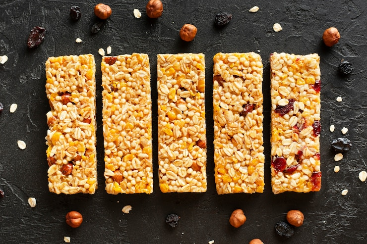

## Posicionamento: Marcas Barrinha de Cereal

As barrinhas de cereal são populares pela praticidade e por serem vistas como opções saudáveis. Nesta análise, avaliamos o posicionamento de quatro marcas (Nutry, Trio, Supino, Sucrilhos) com base em atributos como agradabilidade, crocância, teor de fibras adequado e percepção de saudabilidade, conforme as respostas.

Formulário: https://forms.gle/TwWWqUtUJZBMueRB8

#### Pontos de paridade (atributos em comum entre as marcas):

**Sabor agradável:** Todas as marcas buscam oferecer barras de cereal que sejam saborosas e atrativas ao paladar, independentemente das suas formulações nutricionais.

**Textura:** Um ponto comum entre as barras de cereal é a textura crocante ou macia. Isso é fundamental para a experiência do consumidor e aparece de forma destacada em todas as avaliações das marcas no seu formulário.

**Teor de fibras e proteínas:** As barras de cereal Nutry, Trio, Supino e Sucrilhos são amplamente reconhecidas por oferecer uma quantidade considerável de fibras e proteínas, o que as torna uma escolha saudável para consumo diário.

**Conveniência e praticidade:** Outro ponto de paridade é o foco em serem produtos práticos para o consumo rápido, uma solução nutritiva para quem tem um estilo de vida corrido e precisa de energia ao longo do dia.

O primeiro mapa irá indicar o percentual de explicação do posicionamento das barrinhas no plano bidimensional.

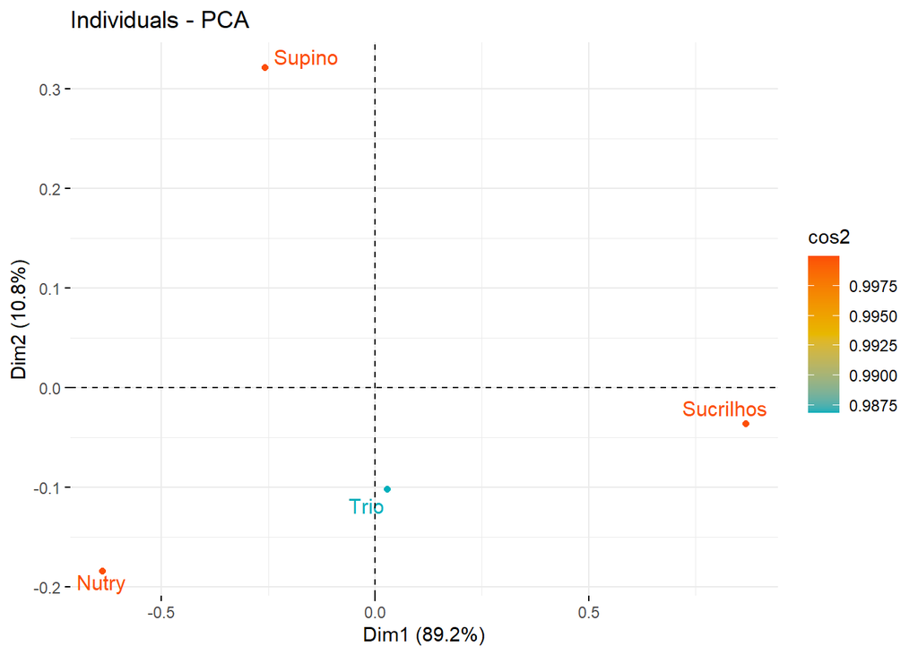

#### Análise dos Resultados

**Nutry** se destacou como a barrinha mais bem avaliada, sendo considerada tanto agradável quanto crocante, além de ter um bom teor de fibras e ser vista como saudável.

**Trio e Supino** apresentam resultados intermediários, com avaliações próximas nos atributos de agradabilidade e crocância, mas com uma leve vantagem para Supino na percepção de teor de fibras e saudabilidade.

**Sucrilhos**, por outro lado, obteve as menores notas, especialmente em saudabilidade, sugerindo que os alunos a percebem mais como um produto voltado ao sabor do que à saúde.

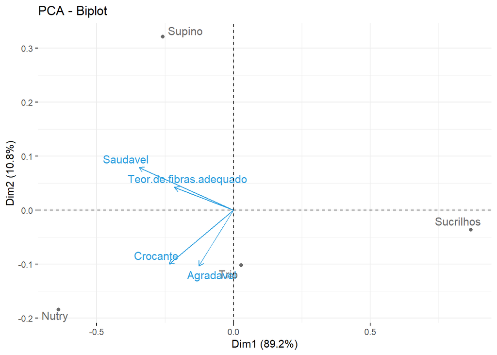

| Barrinhas | Agradável | Crocante | Teor de Fibras Adequado | Saudável |
| --- | --- | --- | --- | --- |
| Nutry | 3.81 | 3.81 | 3.44 | 3.63 |
| Trio | 3.59 | 3.44 | 3.19 | 3.19 |
| Supino | 3.41 | 3.33 | 3.41 | 3.59 |
| Sucrilhos | 3.33 | 3.00 | 2.81 | 2.63 |

Com base nessas percepções, a Nutry parece ser a escolha preferida quando se busca um equilíbrio entre sabor e saúde, enquanto a Sucrilhos se posiciona mais para quem prioriza o prazer ao consumir o produto.

### Marcas Utilizadas

[figure not shown]

[figure not shown]

[figure not shown]

[figure not shown]